# Notebook

```python
import pandas as pd
import numpy as np
import seaborn as sns
import matplotlib.pyplot as plt

from sklearn.model_selection import train_test_split

#normalización
from sklearn.preprocessing import MinMaxScaler, StandardScaler

#reducción de la dimensionalidad
from xgboost  import XGBClassifier, plot_importance
from sklearn.feature_selection import SelectFromModel, RFECV
from mlxtend.feature_selection import SequentialFeatureSelector
import shap

#selección de hiperparámetros
from sklearn.model_selection import GridSearchCV, RandomizedSearchCV, StratifiedKFold

#métricas evaluación
from sklearn.metrics import (
    roc_auc_score,
    roc_curve,
    classification_report,
    confusion_matrix,
    accuracy_score,
    precision_score,
    recall_score,
    f1_score
)

#rebalanceo de clases
from imblearn.over_sampling import SMOTE

#modelado
from sklearn.linear_model import LogisticRegression, LassoCV, RidgeCV
from sklearn.svm import LinearSVC
from sklearn.ensemble import RandomForestClassifier, ExtraTreesClassifier
from xgboost import XGBClassifier

import pickle

import tensorflow as tf
from tensorflow.keras.models import Sequential, load_model
from tensorflow.keras.layers import Dense, Dropout, BatchNormalization, Lambda
from tensorflow.keras.optimizers import Adam
from tensorflow.keras.callbacks import EarlyStopping, ModelCheckpoint
from tensorflow.keras.regularizers import l1, l2

from sklearn.utils.class_weight import compute_class_weight
```

### 1. CARGA DE DATOS

Sólo cargamos los dataset de explotación, para eliminar las mismas variables que en construcción, pero NUNCA entrenar con dichos datos, sólo los cargamos para VALIDAR.

```python
features_const = pd.read_csv('features_const_PD.csv')
```

```python
features_explot = pd.read_csv('features_explot_PD.csv')
```

```python
target_const = pd.read_csv('target_const_PD.csv')
```

```python
target_explot = pd.read_csv('target_explot_PD.csv')
```

### 2. ELIMINAR VARIABLES FECHA

Aunque se trata de variables fecha, están en formato string

```python
features_const.select_dtypes(include=['object']).columns
```

```
Index(['pymnt_plan', 'purpose', 'initial_list_status', 'issue_date',
       'earliest_cr_line_date', 'last_pymnt_date', 'last_credit_pull_date',
       'filtered_emp_title'],
      dtype='object')
```

```python
features_explot.select_dtypes(include=['object']).columns
```

```
Index(['pymnt_plan', 'purpose', 'initial_list_status', 'application_type',
       'issue_date', 'earliest_cr_line_date', 'last_pymnt_date',
       'last_credit_pull_date', 'next_pymnt_date', 'filtered_emp_title'],
      dtype='object')
```

```python
features_const[['earliest_cr_line_date', 'issue_date','last_pymnt_date','last_credit_pull_date']]
```

|  | earliest_cr_line_date | issue_date | last_pymnt_date | last_credit_pull_date |
| --- | --- | --- | --- | --- |
| 0 | 1985-01-01 | 2011-12-01 | 2015-01-01 | 2016-01-01 |
| 1 | 1999-04-01 | 2011-12-01 | 2013-04-01 | 2013-09-01 |
| 2 | 2001-11-01 | 2011-12-01 | 2014-06-01 | 2016-01-01 |
| 3 | 1996-02-01 | 2011-12-01 | 2015-01-01 | 2015-01-01 |
| 4 | 1996-01-01 | 2011-12-01 | 2016-01-01 | 2016-01-01 |
| ... | ... | ... | ... | ... |
| 443776 | 2003-04-01 | 2014-01-01 | 2016-01-01 | 2016-01-01 |
| 443777 | 1997-06-01 | 2014-01-01 | 2014-12-01 | 2016-01-01 |
| 443778 | 2001-12-01 | 2014-01-01 | 2016-01-01 | 2015-12-01 |
| 443779 | 2003-02-01 | 2014-01-01 | 2014-12-01 | 2015-04-01 |
| 443780 | 2000-02-01 | 2014-01-01 | 2016-01-01 | 2016-01-01 |

443781 rows × 4 columns

```python
features_explot[['earliest_cr_line_date', 'issue_date','last_pymnt_date','last_credit_pull_date']]
```

|  | earliest_cr_line_date | issue_date | last_pymnt_date | last_credit_pull_date |
| --- | --- | --- | --- | --- |
| 0 | 1990-02-01 | 2015-12-01 | 2016-01-01 | 2016-01-01 |
| 1 | 2001-07-01 | 2015-12-01 | 2016-01-01 | 2016-01-01 |
| 2 | 2011-07-01 | 2015-12-01 | 2016-01-01 | 2016-01-01 |
| 3 | 1998-12-01 | 2015-12-01 | 2016-01-01 | 2016-01-01 |
| 4 | 2000-08-01 | 2015-12-01 | 2016-01-01 | 2015-12-01 |
| ... | ... | ... | ... | ... |
| 402884 | 2004-09-01 | 2015-01-01 | 2016-01-01 | 2016-01-01 |
| 402885 | 1974-03-01 | 2015-01-01 | 2016-01-01 | 2016-01-01 |
| 402886 | 2003-09-01 | 2015-01-01 | 2016-01-01 | 2016-01-01 |
| 402887 | 2003-10-01 | 2015-01-01 | 2016-01-01 | 2016-01-01 |
| 402888 | 2001-12-01 | 2015-01-01 | 2016-01-01 | 2016-01-01 |

402889 rows × 4 columns

```python
features_const.drop(['earliest_cr_line_date', 'issue_date','last_pymnt_date','last_credit_pull_date'], axis=1, inplace=True)
```

```python
features_explot.drop(['earliest_cr_line_date', 'issue_date','last_pymnt_date','last_credit_pull_date', 'next_pymnt_date'], axis=1, inplace=True)
```

### 3. NORMALIZAR Y ONE-HOT ENCODING

Antes de realizar one-hot encoding a las variables categóricas no ordinales, debemos normalizar las variables numéricas y las variables categórica ordinales

#### NORMALIZAR

```python
#seleccionamos las variables numéricas
numeric_columns_const = features_const.select_dtypes(include=['number']).columns
```

```python
numeric_columns_explot = features_explot.select_dtypes(include=['number']).columns
```

```python
#Normalizamos variables numéricas
scaler = MinMaxScaler()
features_const[numeric_columns_const] = scaler.fit_transform(features_const[numeric_columns_const])
```

```python
scaler = MinMaxScaler()
features_explot[numeric_columns_explot] = scaler.fit_transform(features_explot[numeric_columns_explot])
```

#### ONE-HOT ENCODING

```python
#Seleccionamos las variables categóricas
categorical_columns_const  = features_const.select_dtypes(include=['object']).columns

#Aplicamos One-Hot Encoding sólo a las variables categóricas
one_hot_encoded_const = pd.get_dummies(features_const[categorical_columns_const], drop_first=True)   #drop_first=True: Elimina la primera categoría de cada columna para evitar colinealidad.

# Combinar el resultado con el DataFrame original excluyendo las columnas categóricas originales
features_const = pd.concat([features_const.drop(columns=categorical_columns_const), one_hot_encoded_const], axis=1)
```

```python
#Seleccionamos las variables categóricas
categorical_columns_explot  = features_explot.select_dtypes(include=['object']).columns

#Aplicamos One-Hot Encoding sólo a las variables categóricas
one_hot_encoded_explot = pd.get_dummies(features_explot[categorical_columns_explot], drop_first=True)   #drop_first=True: Elimina la primera categoría de cada columna para evitar colinealidad.

# Combinar el resultado con el DataFrame original excluyendo las columnas categóricas originales
features_explot = pd.concat([features_explot.drop(columns=categorical_columns_explot), one_hot_encoded_explot], axis=1)
```

Vemos como finalmente nos hemos quedado con 75 variables (76 en explotación), las cuáles vamos a reducir su dimensionalidad en el siguiente paso.

```python
features_const.shape, features_explot.shape
```

```
((443781, 75), (402889, 76))
```

### 4. SEPARACIÓN TRAIN Y TEST

```python
X_train, X_test, y_train, y_test = train_test_split(
    features_const,
    target_const,
    test_size=0.2,
    stratify=target_const,
    random_state=42
)
```

```python
X_train.shape, X_test.shape
```

```
((355024, 75), (88757, 75))
```

```python
y_train.shape, y_test.shape
```

```
((355024, 1), (88757, 1))
```

Observamos que tanto en `train`como en `test`la proporción de **defaults** se mantiene. Mientras que para el conjunto de `validación`, la proporción cae drásticamente, ya que **se pasa de un 10% de default a menos de un 2% de default**.  
**Esto tiene suma importancia ya que provocará que los scores de todos los modelos caigan drásticamente, aunque a unos niveles aún aceptables.**

```python
y_train.value_counts()/len(y_train)
```

```
default
0          0.898097
1          0.101903
Name: count, dtype: float64
```

```python
y_test.value_counts()/len(y_test)
```

```
default
0          0.898093
1          0.101907
Name: count, dtype: float64
```

```python
target_explot.value_counts()/len(target_explot)
```

```
default
0          0.983432
1          0.016568
Name: count, dtype: float64
```

Asegurarse de que las etiquetas de la variable TARGET tengan la forma correcta para que no nos de aviso de fallo al modelar

```python
y_train = y_train.to_numpy().ravel()  # Convierte a NumPy y luego aplica ravel
y_test = y_test.to_numpy().ravel()    # Convierte a NumPy y luego aplica ravel
target_explot = target_explot.to_numpy().ravel()
```

### 5. REDUCCIÓN DIMENSIONALIDAD

Reducir el número de variables que el modelo tiene en cuenta es fundamental para evitar el overfitting de los modelos, sino lo que ocurriría sería que tendríamos scores muy altos para los conjuntos de entrenamiento y muy bajos para los de test.  
**Además, vamos a utilizar este paso para darle explicabilidad a los modelos, de tal forma que las variables utilizadas por los modelos así cómo su importancia sea visibles para el usuario**

Tal y cómo veremos a continuación, existen principalmente 3 grandes métodos, Filter, Wrapper y Embedded. Nosotros nos vamos a centrar en este último debido a algunos incovenientes que presentan los otros 2 métodos.

5.1 MÉTODO FILTER

Se pueden dar 4 casos:

- Variables numéricas y target numérica --> método de **correlación de Pearson**
- Variables numéricas y target categórica --> método **F-score de ANOVA**
- Variables categóricas y target categórica --> método de **chi cuadrado**
- Variables categóricas y target numérica --> caso poco frecuente

Al tratarse de un problema de clasificación binario, sólo podríamos emplear en método F-score o el método chi cuadrado. Pero en cualquier caso, no vamos a utilizar ninguno de estos métodos puesto que en nuestro dataset tenemos un mix de variables categóricas y contínuas, y deberíamos de emplear ambos métodos, de tal manera que no se tendrían en cuenta todas las variables en conjunto, por lo que para la eliminación de variables es preferible utilizar alguno de los métodos siguientes que se explican a continuación.

5.2 MÉTODO WRAPPER: RECURSIVE FEATURE ELIMINATION

El principal problema de estos métodos es que son MUY lentos computacionalmente.

Además en el caso de los métodos forward/backward tiene el incoveniente que tenemos que indicar, de antemano, el número de variables con las que nos queremos quedar, lo cuál en la mayoría de las ocasiones no lo vamos a saber

**FORWARD**

Partiendo de una sola variable, se van construyendo conjuntos de variables de, cada vez, más tamaño mientras se mejore una métrica de calidad.

```python
#Creamos el método forward con un modelo Random Forest
# feature_selecto_forward = SequentialFeatureSelector(RandomForestClassifier(n_estimators=10), k_features=15, forward=True, verbose=2, scoring='roc_auc', cv=10) #no emplear acuracy cuando la variable objetivo está desbalanceada
```

```python
#Entrenamos el modelo
# feature_selecto_forward = feature_selecto_forward.fit(X_train, y_train)
```

```python
#ver cuáles son las variables seleccionadas
# feature_selecto_forward.k_feature_names_
```

```python
#ver el score del modelo
# feature_selecto_forward.k_score_
```

**BACKWARD**

Partiendo de un conjunto formado por todas las variables, se van construyendo conjuntos de variables de, cada vez, menos tamaño, mientras se mejore una métrica de calidad.

El código es igual que el anterior pero cambiando el hiperparámetro `forward`

```python
#Creamos el método forward con un modelo Random Forest
# feature_selector_backward = SequentialFeatureSelector(RandomForestClassifier(n_estimators=10), k_features=15, forward=False, verbose=2, scoring='roc_auc', cv=10) #no emplear acuracy cuando la variable objetivo está desbalanceada
```

```python
#Entrenamos el modelo
# feature_selecto_backward = feature_selecto_backward.fit(X_train, y_train)
```

```python
#ver cuáles son las variables seleccionadas
# feature_selecto_backward.k_feature_names_
```

```python
#ver el score del modelo
# feature_selecto_backward.k_score_
```

**RECURSIVE FEATURE ELIMINATION**

Similar al método backward, pero con algunas diferencias:

- Clasifica las características según su importancia (usando pesos o importancia de características del modelo).
- Elimina iterativamente la característica menos importante (una o varias a la vez) y vuelve a entrenar el modelo con las características restantes.

```python
#Creamos el modelo (en este caso una regresión logística, pero podría ser cualquier otro)

# model=LogisticRegression(solver="liblinear")
# rfecv = RFECV(estimator=model, step=1, cv=StratifiedKFold(2), scoring='roc_auc')
```

```python
#Entrenamos el modelo

# rfecv.fit(X_train, y_train)
```

```python
#Ver cuáles han sido las mejores variables

# rfecv.support_
```

```python
#Ver el score del modelo

# rfecv.k_score_
```

5.3 MÉTODO EMBEDDED

Se usa la información proporcionada por los propios modelos para obtener una medida de la importancia que tienen las variables en la construcción del modelo

**LASSO (L1)**

Hemos observado que utilizando un umbral de 0.25, el ROC_AUC en explotación se optimiza (No obtenemos mejores resultados utilizando más variables)

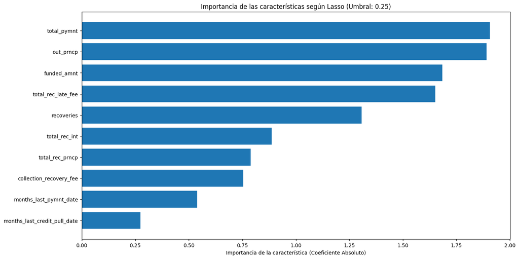

```python
# Modelo Lasso con validación cruzada para encontrar el mejor alpha
lasso = LassoCV(cv=5, random_state=42).fit(X_train, y_train)

# Selección de variables con SelectFromModel
model = SelectFromModel(lasso, prefit=True)

# Obtenemos las importancias de las características (coeficientes absolutos)
feature_importances = np.abs(lasso.coef_)

# Nombres de las variables
feature_names = X_train.columns.tolist()

# Definimos el umbral para seleccionar características
threshold = 0.25

# Filtramos características por encima del umbral
selected_indices = np.where(feature_importances > threshold)[0]
selected_feature_names = [feature_names[i] for i in selected_indices]
selected_importances = feature_importances[selected_indices]


# Ordenamos las características seleccionadas por importancia
sorted_indices = np.argsort(selected_importances)[::-1]
sorted_importances = selected_importances[sorted_indices]
sorted_variable_names = [selected_feature_names[i] for i in sorted_indices]

# Graficamos las importancias de las características seleccionadas
plt.figure(figsize=(15, 8))
plt.barh(sorted_variable_names, sorted_importances, align='center')
plt.xlabel('Importancia de la característica (Coeficiente Absoluto)')
plt.title(f'Importancia de las características según Lasso (Umbral: {threshold})')
plt.gca().invert_yaxis()  # Invertimos el eje Y para que la más importante esté arriba
plt.show()
```

```python
#vemos cuáles son esas variables
sorted_variable_names
```

```
['total_pymnt',
 'out_prncp',
 'funded_amnt',
 'total_rec_late_fee',
 'recoveries',
 'total_rec_int',
 'total_rec_prncp',
 'collection_recovery_fee',
 'months_last_pymnt_date',
 'months_last_credit_pull_date']
```

Observamos que existen correlaciones muy altas entre las variables, pero no vamos a eliminarlas puesto son las seleccionadas por el modelo como las que mejor score se obtiene para el conjunto de entrenamiento.

```python
#Filtramos nuestros datasets con las variables más importantes seleccionadas por este modelo
X_train_lasso = X_train[sorted_variable_names]
X_test_lasso = X_test[sorted_variable_names]
features_explot_lasso = features_explot[sorted_variable_names]
```

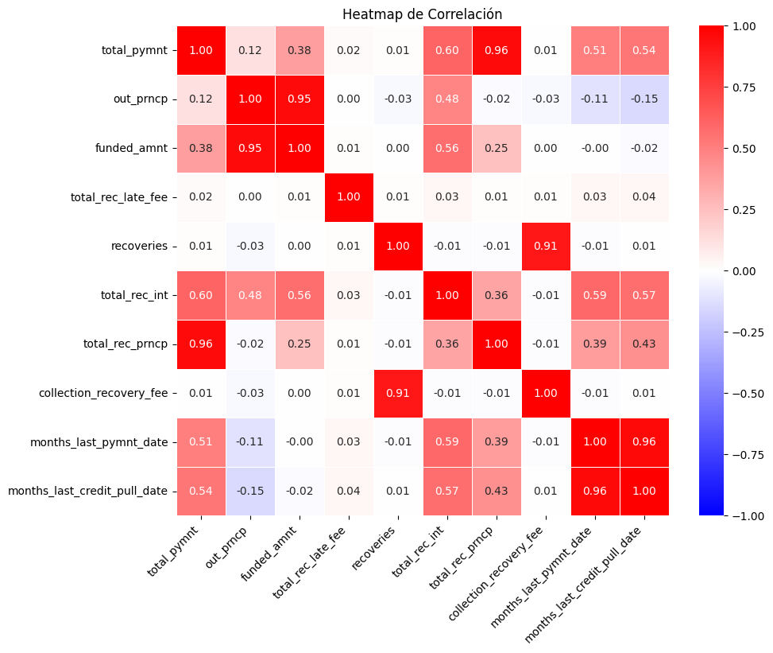

```python
plt.figure(figsize=(10, 8))  # Ajusta el tamaño según el número de variables
sns.heatmap(features_explot_lasso.corr(), cmap="bwr", vmin=-1, vmax=1, annot=True, fmt=".2f", linewidths=0.5)

# Mejorar legibilidad de las etiquetas
plt.xticks(rotation=45, ha='right')
plt.yticks(rotation=0)

plt.title("Heatmap de Correlación")
plt.show()
```

```python
X_test_lasso.shape, features_explot_lasso.shape
```

```
((88757, 10), (402889, 10))
```

**RANDOM FOREST / EXTRATREES**

En un RandomForestClassifier, las variables más importantes se seleccionan a partir de las divisiones realizadas en los árboles del bosque. Específicamente:

- Reducción promedio de la impureza: Cada vez que una característica se utiliza para dividir un nodo en un árbol, contribuye a reducir la impureza del nodo (medida, por ejemplo, con el índice Gini).
- La importancia se calcula como la reducción total (o promedio ponderado) de impureza atribuible a una característica en todos los árboles del bosque.

Nos quedamos con aquellas variables que explican más del 0,1% de la predicción del modelo, ya que hemos observado empíricamente que **incrementar el número de variables por encima de este umbral NO supone un incremento del score en explotación**.

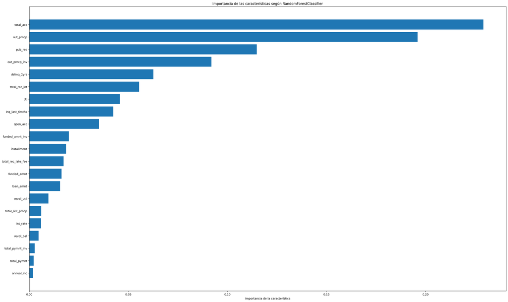

```python
random_forest = RandomForestClassifier (max_depth = 5).fit(X_train, y_train)

# Selección de las variables más importantes
model = SelectFromModel (random_forest, prefit=True) #prefit=True indica si el modelo fue entrenado antes de pasarlo a SelectFromModel, En este caso, el modelo no será reentrenado

# Obtenemos las importancias de las características
feature_importances = random_forest.feature_importances_

# Definir los nombres de las variables y un umbral
feature_names = X_train.columns.tolist()
threshold = 0.001

#filtrar las características por encima de ese umbral
selected_indices = np.where(feature_importances > threshold)[0]
selected_feature_names = [feature_names[i] for i in selected_indices]
selected_importances = feature_importances[selected_indices]


# Ordenamos las características por importancia
sorted_indices = np.argsort(selected_importances)[::-1]
sorted_importances = selected_importances[sorted_indices]
sorted_variable_names = [feature_names[i] for i in sorted_indices]

# Graficamos las importancias
plt.figure(figsize=(30, 18))
plt.barh(sorted_variable_names, sorted_importances, align='center')
plt.xlabel('Importancia de la característica')
plt.title('Importancia de las características según RandomForestClassifier')
plt.gca().invert_yaxis()  # Invertimos el eje Y para que la más importante esté arriba
plt.show()
```

```python
#Aplicamos las variables seleccionadas a los conjuntos de entrenamiento, test y validación
X_train_rf = X_train[sorted_variable_names]
X_test_rf = X_test[sorted_variable_names]
features_explot_rf = features_explot[sorted_variable_names]
```

```python
sorted_variable_names
```

```
['total_acc',
 'out_prncp',
 'pub_rec',
 'out_prncp_inv',
 'delinq_2yrs',
 'total_rec_int',
 'dti',
 'inq_last_6mths',
 'open_acc',
 'funded_amnt_inv',
 'installment',
 'total_rec_late_fee',
 'funded_amnt',
 'loan_amnt',
 'revol_util',
 'total_rec_prncp',
 'int_rate',
 'revol_bal',
 'total_pymnt_inv',
 'total_pymnt',
 'annual_inc']
```

```python
X_test_rf.shape, features_explot_rf.shape
```

```
((88757, 21), (402889, 21))
```

**XGBOOST**

El método `plot_importance` de XGBoost se basa en:

- Frecuencia: cuantas veces se usa cada variable en la divisiones de los árboles
- Ganancia: cuanto mejora la métrica de división (Ej:Gini, Entropía...)
- Cobertura: cuantos datos se ven afectados por cada variable.

La interpretación es la siguiente:

- Variables con mayor importancia fueron más usadas para dividir nodos en los árboles
- **No significa que tengan el mayor impacto real en la predicción (aquí es dónde SHAP es más preciso)**

```python
# Calcular el peso para la clase positiva (esto es lo mismo que el class_weight = "balanced" del random forest)
# scale_pos_weight = sum(y_train == 0) / sum(y_train == 1)
# scale_pos_weight
```

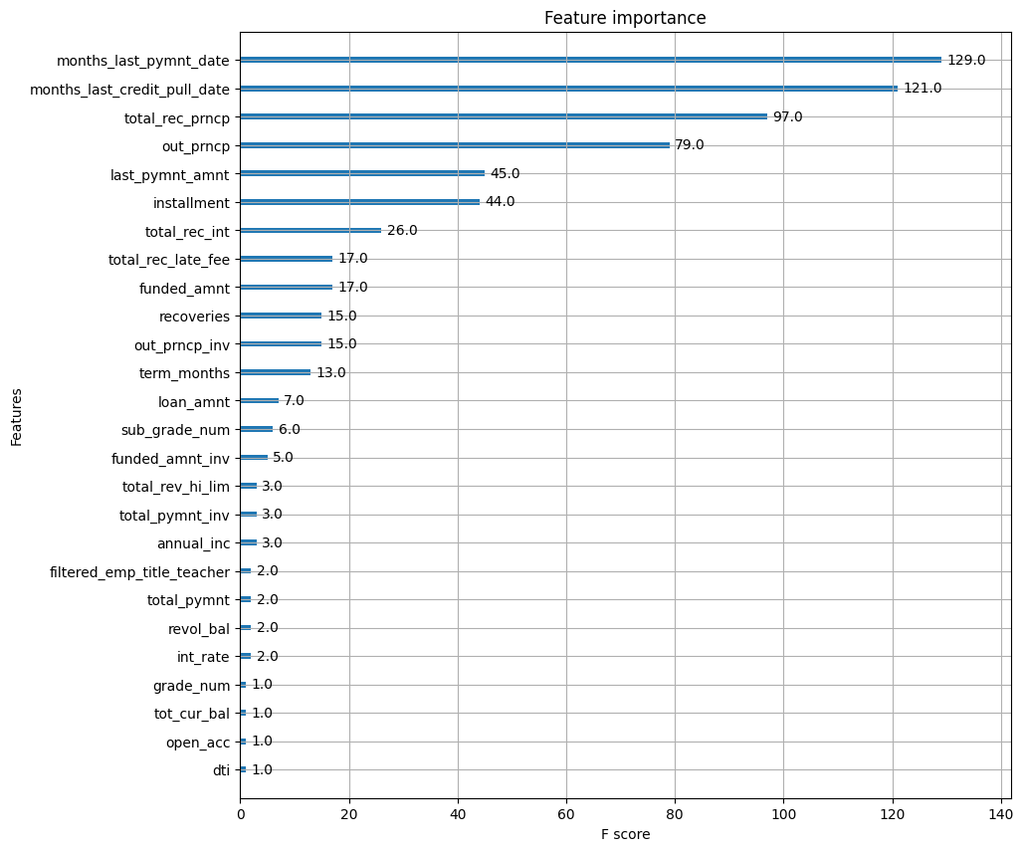

```python
xgb = XGBClassifier(max_depth=3, min_child_weight=5, gamma=0.3) #scale_pos_weight=scale_pos_weight)

xgb_model = xgb.fit(X_train, y_train)

# Crear la figura
fig, ax = plt.subplots(figsize=(10, 10))

# Mostrar la importancia de las características
plot_importance(xgb, ax=ax)

# Mostrar la gráfica
plt.show()
```

Hemos observado que para un umbral de F score por encima de 10, en explotación el score no mejora aunque incrementemos el número de variables

```python
# Extraer todas las variables ordenadas del gráfico
all_features = [text.get_text() for text in ax.get_yticklabels()]

# Extraer los valores del F score directamente desde el modelo
importance_dict = xgb.get_booster().get_score(importance_type='weight')

# Crear un DataFrame con las variables y su F score
importance_df = pd.DataFrame({
    'Feature': list(importance_dict.keys()),
    'F_score': list(importance_dict.values())
})

# Filtrar las variables con un F score por encima de un umbral
threshold = 10
important_features = importance_df[importance_df['F_score'] > threshold]

# Si quieres quedarte con solo los nombres de las variables:
important_features = important_features['Feature'].tolist()
important_features
```

```
['funded_amnt',
 'installment',
 'out_prncp',
 'out_prncp_inv',
 'total_rec_prncp',
 'total_rec_int',
 'total_rec_late_fee',
 'recoveries',
 'last_pymnt_amnt',
 'term_months',
 'months_last_pymnt_date',
 'months_last_credit_pull_date']
```

```python
# Reducimos el número de variables a las que más información aportan al modelo, tanto para el conjunto train como para el conjunto test y explotación

X_train_xgb = X_train[important_features]
X_test_xgb = X_test[important_features]
features_explot_xgb = features_explot[important_features]
```

```python
X_test_xgb.shape, features_explot_xgb.shape
```

```
((88757, 12), (402889, 12))
```

### 7. CREAR FUNCIÓN CON MÉTRICAS DE EVALUACIÓN

```python
def evaluate_model(model, X_train, y_train, X_test, y_test):

    # Predicciones y probabilidades para el conjunto de entrenamiento
    y_train_pred = model.predict(X_train)
    y_train_proba = model.predict_proba(X_train)[:, 1]

    # Predicciones y probabilidades para el conjunto de prueba
    y_test_pred = model.predict(X_test)
    y_test_proba = model.predict_proba(X_test)[:, 1]

    # ROC AUC para el conjunto de entrenamiento
    train_roc_auc = roc_auc_score(y_train, y_train_proba)
    # ROC AUC para el conjunto de prueba
    test_roc_auc = roc_auc_score(y_test, y_test_proba)

    print("\n--- Entrenamiento ---")
    print("ROC AUC:", train_roc_auc)
    print("Confusion Matrix:")
    print(confusion_matrix(y_train, y_train_pred))
    print("\nClassification Report:")
    print(classification_report(y_train, y_train_pred))

    print("\n--- Prueba ---")
    print("ROC AUC:", test_roc_auc)
    print("Confusion Matrix:")
    print(confusion_matrix(y_test, y_test_pred))
    print("\nClassification Report:")
    print(classification_report(y_test, y_test_pred))

    # Curva ROC
    fpr_train, tpr_train, _ = roc_curve(y_train, y_train_proba)
    fpr_test, tpr_test, _ = roc_curve(y_test, y_test_proba)

    plt.figure(figsize=(10, 6))
    plt.plot(fpr_train, tpr_train, label="Train ROC (AUC = {:.2f})".format(train_roc_auc))
    plt.plot(fpr_test, tpr_test, label="Test ROC (AUC = {:.2f})".format(test_roc_auc))
    plt.plot([0, 1], [0, 1], "k--", label="Random Guess")
    plt.xlabel("False Positive Rate")
    plt.ylabel("True Positive Rate")
    plt.title("ROC Curve")
    plt.legend()
    plt.show()
```

### 8. AJUSTE DE HIPERPARÁMETROS Y MODELADO

**REGRESIÓN LOGÍSTICA**

```python
%%time
model_lr = LogisticRegression(
    penalty='l2', #(Ridge): reduce el tamaño de los coeficientes, pero sin hacerlos 0.
    C=0.01, #Controla la penalización de los coeficientes (inversa de la regularización).
    solver='lbfgs', #por defecto en L2, recomendado para datasets medianos a grandes.
    max_iter=100, # max_iter asegura convergencia
    class_weight = 'balanced',#'balanced': ajusta automáticamente los pesos de cada clase.
    random_state=42

)


model_lr.fit(X_train_lasso, y_train)
```

```
CPU times: user 1.84 s, sys: 365 ms, total: 2.21 s
Wall time: 1.17 s
```

```
LogisticRegression(C=0.01, class_weight='balanced', random_state=42)
```

```python
# Hacer predicciones
y_train_pred_lr = model_lr.predict(X_train_lasso)
y_test_pred_lr = model_lr.predict(X_test_lasso)
```

```python
# Calcular probabilidades para ROC AUC
y_train_proba_lr = model_lr.predict_proba(X_train_lasso)[:, 1]
y_test_proba_lr = model_lr.predict_proba(X_test_lasso)[:, 1]
```

Si entrenásemos todas las variables en lugar de las X primeras, veríamos como el roc_auc es el mismo tanto para el conjunto test como para el conjunto train. Pero de esta manera obtenemos un ahorro computacional elevado, que se notará aún más en otros modelos para complejos que en la regresión logística.

```
--- Entrenamiento ---
ROC AUC: 0.9468891323807014
Confusion Matrix:
[[315218   3628]
 [  6820  29358]]

Classification Report:
              precision    recall  f1-score   support

           0       0.98      0.99      0.98    318846
           1       0.89      0.81      0.85     36178

    accuracy                           0.97    355024
   macro avg       0.93      0.90      0.92    355024
weighted avg       0.97      0.97      0.97    355024


--- Prueba ---
ROC AUC: 0.9454383874818334
Confusion Matrix:
[[78838   874]
 [ 1700  7345]]

Classification Report:
              precision    recall  f1-score   support

           0       0.98      0.99      0.98     79712
           1       0.89      0.81      0.85      9045

    accuracy                           0.97     88757
   macro avg       0.94      0.90      0.92     88757
weighted avg       0.97      0.97      0.97     88757
```

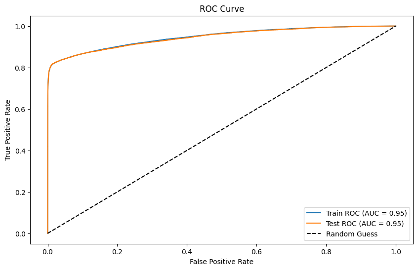

```python
evaluate_model(model_lr, X_train_lasso, y_train, X_test_lasso, y_test)
```

**RANDOM FOREST**

Selección de hiperparámetros mediante **GridSearch** (no está en formato código porque es muy costoso computacionalmente y hay que ejecutar el notebook con una instacia más potente de AWS que la que hemos usado pata el resto del notebook).

```python
# Definir el modelo a emplear.Se podría hacer también con ExtraTreesClassifier()

# random_forest = RandomForestClassifier (class_weight = "balanced")
```

```python
#ver normbre de los hiperparámetros del modelo

# random_forest.get_params().keys()
```

```python
# max_depth= [5, 10, 15]
# n_estimators = [100, 200, 500]
# min_samples_split = [2, 5, 10]
# min_samples_leaf = [1, 2, 4]
```

```python
# hiperparametros = dict(n_estimators= n_estimators, max_depth=max_depth, min_samples_split=min_samples_split, min_samples_leaf=min_samples_leaf)
```

```python
#En lugar de GridSearchCV podríamos aplicar RandomizedSearchCV

# grid_search = GridSearchCV(random_forest, hiperparametros, cv=5, n_jobs=-1, scoring="roc_auc")
```

```python
#Entrenar los modelos (3x3x3x3 = 81 modelos)

# rf_model = grid_search.fit(X_train, y_train)
```

```python
#obtener la combinación de hiperparámetros que mejor score nos da

# rf_model.best_estimator_.get_params()
```

Entrenamos el modelo con los hiperparámetros con los que se obtiene mejor score.

```python
# Crear y entrenar el modelo de Random Forest

model_rf = RandomForestClassifier(
    n_estimators=100, #Número de árboles en el bosque.
    max_depth=5, #profundidad máxima de los árboles
    min_samples_split=5,  #Número mínimo de muestras requeridas para dividir un nodo (cuanto más alto menos sobreajuste)
    min_samples_leaf=3, #Número mínimo de muestras requeridas en una hoja (cuanto más alto menos sobreajuste)
    max_features='sqrt', #Número máximo de features consideradas en cada división.
    bootstrap=True,  #Si True, usa muestreo con reemplazo, lo que ayuda a la generalización
    random_state=32,
    n_jobs=-1,
    class_weight = "balanced"
)

model_rf.fit(X_train_rf, y_train)
```

```
RandomForestClassifier(class_weight='balanced', max_depth=5, min_samples_leaf=3,
                       min_samples_split=5, n_jobs=-1, random_state=32)
```

```python
# Hacer predicciones
y_train_pred_rf = model_rf.predict(X_train_rf)
y_test_pred_rf = model_rf.predict(X_test_rf)
```

```python
# Calcular probabilidades para ROC AUC
y_train_proba_rf = model_rf.predict_proba(X_train_rf)[:, 1]
y_test_proba_rf = model_rf.predict_proba(X_test_rf)[:, 1]
```

```
--- Entrenamiento ---
ROC AUC: 0.9549685774665981
Confusion Matrix:
[[311104   7742]
 [  6769  29409]]

Classification Report:
              precision    recall  f1-score   support

           0       0.98      0.98      0.98    318846
           1       0.79      0.81      0.80     36178

    accuracy                           0.96    355024
   macro avg       0.89      0.89      0.89    355024
weighted avg       0.96      0.96      0.96    355024


--- Prueba ---
ROC AUC: 0.9530610155098985
Confusion Matrix:
[[77864  1848]
 [ 1708  7337]]

Classification Report:
              precision    recall  f1-score   support

           0       0.98      0.98      0.98     79712
           1       0.80      0.81      0.80      9045

    accuracy                           0.96     88757
   macro avg       0.89      0.89      0.89     88757
weighted avg       0.96      0.96      0.96     88757
```

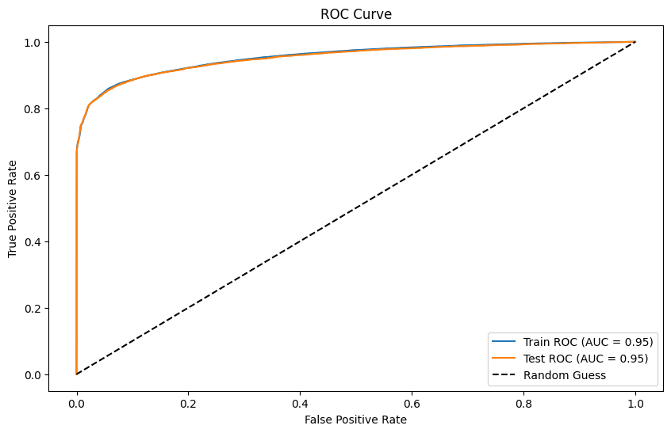

```python
evaluate_model(model_rf, X_train_rf, y_train, X_test_rf, y_test)
```

**XGBOOST**

Búsqueda aleatoria con **RandomizedSearch** (no está en formato código porque es muy costoso computacionalmente y hay que ejecutar el notebook con una instacia más potente de AWS que la que hemos usado pata el resto del notebook).

```python
# xgb =  XGBClassifier(class_weight = "balanced")
```

```python
# xgb.get_params().keys()
```

```python
# n_estimator = [20, 50]
# learning_rate = [0.00000001, 0.000001]
# max_depth= [2,3]
# subsample = [0.2, 0.3, 0.5]
```

```python
# hiperparametros = dict(XGBClassifier_n_estimators= n_estimator, XGBClassifier_learning_rate=learning_rate, XGBClassifier_max_depth=max_depth, XGBClassifier_subsample=subsample)
```

```python
# random_search = RandomizedSearchCV(xgb, hiperparametros, cv=5, n_jobs=-1, n_iter=100, scoring="roc_auc")
```

```python
#Entrenar los modelos

# xgb_model = random_search.fit(X_train, y_train)
```

```python
#ver la combiación de hiperparámetros que optimiza el roc_auc

# xgb_model.best_estimator_.get_params()
```

Entrenamos el modelo con los hiperparámetros con los que se obtiene mejor score.

```python
model_xgb = XGBClassifier(
    max_depth=4, #Define la profundidad máxima de los árboles.
    min_child_weight=6, #Define la cantidad mínima de observaciones necesarias en un nodo hijo antes de dividirse.
    gamma=0.2, #Define la reducción mínima en la pérdida para hacer una nueva división en un nodo.
    reg_lambda=3, #Controla la penalización de los coeficientes grandes (similar a Ridge Regression).
    reg_alpha=2, #Induce sparsity (puede ayudar si hay muchas variables irrelevantes).
    colsample_bytree=0.7, #Porcentaje de variables usadas en cada árbol.
    learning_rate=0.05, #Reduce el impacto de cada árbol en la predicción final.
    n_estimators=500, #Número de árboles a entrenar.
    random_state=42,
    class_weight = "balanced",
    n_jobs=-1
)

model_xgb.fit(X_train_xgb, y_train)
```

```
XGBClassifier(base_score=None, booster=None, callbacks=None,
              class_weight='balanced', colsample_bylevel=None,
              colsample_bynode=None, colsample_bytree=0.7, device=None,
              early_stopping_rounds=None, enable_categorical=False,
              eval_metric=None, feature_types=None, gamma=0.2, grow_policy=None,
              importance_type=None, interaction_constraints=None,
              learning_rate=0.05, max_bin=None, max_cat_threshold=None,
              max_cat_to_onehot=None, max_delta_step=None, max_depth=4,
              max_leaves=None, min_child_weight=6, missing=nan,
              monotone_constraints=None, multi_strategy=None, n_estimators=500,
              n_jobs=-1, num_parallel_tree=None, ...)
```

```python
# Hacer predicciones
y_train_pred_xgb = model_xgb.predict(X_train_xgb)
y_test_pred_xgb = model_xgb.predict(X_test_xgb)
```

```python
# Calcular probabilidades para ROC AUC
y_train_proba_xgb = model_xgb.predict_proba(X_train_xgb)[:, 1]
y_test_proba_xgb = model_xgb.predict_proba(X_test_xgb)[:, 1]
```

```
--- Entrenamiento ---
ROC AUC: 0.9970455764339965
Confusion Matrix:
[[318818     28]
 [  2159  34019]]

Classification Report:
              precision    recall  f1-score   support

           0       0.99      1.00      1.00    318846
           1       1.00      0.94      0.97     36178

    accuracy                           0.99    355024
   macro avg       1.00      0.97      0.98    355024
weighted avg       0.99      0.99      0.99    355024


--- Prueba ---
ROC AUC: 0.9957500158392213
Confusion Matrix:
[[79705     7]
 [  546  8499]]

Classification Report:
              precision    recall  f1-score   support

           0       0.99      1.00      1.00     79712
           1       1.00      0.94      0.97      9045

    accuracy                           0.99     88757
   macro avg       1.00      0.97      0.98     88757
weighted avg       0.99      0.99      0.99     88757
```

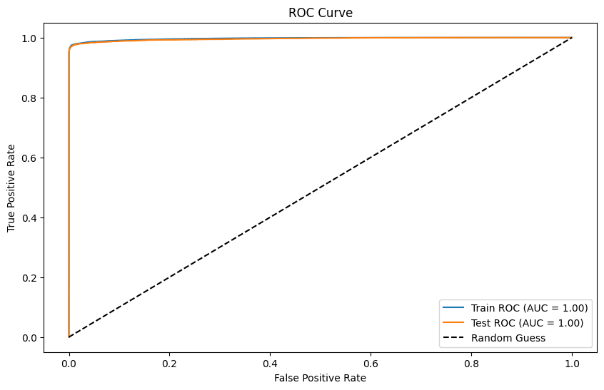

```python
evaluate_model(model_xgb, X_train_xgb, y_train, X_test_xgb, y_test)
```

**RED NEURONAL**

En primer lugar, puesto que no hemos llevado a cabo ninguna reducción de la dimensionalidad, nos vamos a quedar sólo con las variables que se encuentren tanto en entrenamiento/test y en validación.

```python
# Encontrar columnas comunes entre X_train y features_explot
common_columns = list(set(X_train.columns) & set(features_explot.columns))

# Filtrar ambos DataFrames para conservar solo las columnas en común
X_train_nn = X_train[common_columns]
X_test_nn = X_test[common_columns]
features_explot_nn = features_explot[common_columns]
```

```python
X_train_nn.shape, features_explot_nn.shape
```

```
((355024, 64), (402889, 64))
```

```python
# Definir el coeficiente de regularización L2
lambda_l1 = 0.05

model = Sequential([
    Dense(128, activation='relu', input_shape=(X_train_nn.shape[1],), kernel_regularizer=l1(lambda_l1)),
    BatchNormalization(),
    Dropout(0.2),

    Dense(64, activation='relu', kernel_regularizer=l1(lambda_l1)),
    BatchNormalization(),
    Dropout(0.2),

    Dense(32, activation='relu', kernel_regularizer=l1(lambda_l1)),
    Dropout(0.1),

    Dense(1, activation='sigmoid')  # Salida binaria
])
```

[output not shown]

```python
# Compilar el modelo
model.compile(
    optimizer=Adam(learning_rate=0.00001, decay=1e-6),  #una tasa de apredije menor a 0.0001, la red da unos saltos demasiado grandes, no llegando en ocasiones a coverger en resultados óptimos
    loss='binary_crossentropy',
    metrics=['AUC']
)
```

```python
# Callback para parada temprana
early_stopping = EarlyStopping(
    monitor='val_loss',  # Métrica a monitorear
    patience=3,          # Número de épocas sin mejora antes de detener el entrenamiento
    restore_best_weights=True  # Restaurar los pesos del mejor modelo
)
```

```python
# Callback para guardar el modelo después de cada época
checkpoint_callback = ModelCheckpoint(
    filepath='clasificador_nn_PD.keras',  # Nombre del archivo donde se guarda
    monitor='val_loss',               # Métrica a monitorear
    save_best_only=True,              # Guardar solo el mejor modelo
    mode='min',                       # Minimizar la métrica (val_loss en este caso)
    verbose=1                         # Mostrar mensajes de guardado
)
```

```python
# Calcular pesos de clase para datasets desbalanceados
class_weights = compute_class_weight('balanced', classes=[0, 1], y=y_train)
class_weight_dict = {0: class_weights[0], 1: class_weights[1]}
```

```python
# Entrenar el modelo con los datos balanceados
history = model.fit(
    X_train_nn, y_train,
    validation_data=(X_test_nn, y_test),
    epochs=30,              # Número máximo de épocas (parada temprana detendrá antes si es necesario)
    batch_size=128,
    callbacks=[early_stopping, checkpoint_callback],  # Añadir los callbacks
    verbose=1,
    class_weight=class_weight_dict,
)
```

```
2759/2774 ━━━━━━━━━━━━━━━━━━━━ 0s 3ms/step - AUC: 0.4946 - loss: 79.8208
Epoch 1: val_loss improved from inf to 63.00153, saving model to clasificador_nn_PD.keras
2774/2774 ━━━━━━━━━━━━━━━━━━━━ 12s 3ms/step - AUC: 0.4947 - loss: 79.7879 - val_AUC: 0.5595 - val_loss: 63.0015
2770/2774 ━━━━━━━━━━━━━━━━━━━━ 0s 3ms/step - AUC: 0.5445 - loss: 58.0289
Epoch 2: val_loss improved from 63.00153 to 43.92562, saving model to clasificador_nn_PD.keras
2774/2774 ━━━━━━━━━━━━━━━━━━━━ 9s 3ms/step - AUC: 0.5445 - loss: 58.0202 - val_AUC: 0.6200 - val_loss: 43.9256
2769/2774 ━━━━━━━━━━━━━━━━━━━━ 0s 3ms/step - AUC: 0.5776 - loss: 39.8092
Epoch 3: val_loss improved from 43.92562 to 28.41362, saving model to clasificador_nn_PD.keras
2774/2774 ━━━━━━━━━━━━━━━━━━━━ 9s 3ms/step - AUC: 0.5776 - loss: 39.8007 - val_AUC: 0.6638 - val_loss: 28.4136
2766/2774 ━━━━━━━━━━━━━━━━━━━━ 0s 3ms/step - AUC: 0.6114 - loss: 25.1850
Epoch 4: val_loss improved from 28.41362 to 16.51738, saving model to clasificador_nn_PD.keras
2774/2774 ━━━━━━━━━━━━━━━━━━━━ 9s 3ms/step - AUC: 0.6114 - loss: 25.1752 - val_AUC: 0.6974 - val_loss: 16.5174
2772/2774 ━━━━━━━━━━━━━━━━━━━━ 0s 3ms/step - AUC: 0.6446 - loss: 14.1762
Epoch 5: val_loss improved from 16.51738 to 8.19418, saving model to clasificador_nn_PD.keras
2774/2774 ━━━━━━━━━━━━━━━━━━━━ 9s 3ms/step - AUC: 0.6446 - loss: 14.1739 - val_AUC: 0.7370 - val_loss: 8.1942
2769/2774 ━━━━━━━━━━━━━━━━━━━━ 0s 3ms/step - AUC: 0.7093 - loss: 6.7207
Epoch 6: val_loss improved from 8.19418 to 3.30729, saving model to clasificador_nn_PD.keras
2774/2774 ━━━━━━━━━━━━━━━━━━━━ 9s 3ms/step - AUC: 0.7094 - loss: 6.7179 - val_AUC: 0.9011 - val_loss: 3.3073
2770/2774 ━━━━━━━━━━━━━━━━━━━━ 0s 3ms/step - AUC: 0.8709 - loss: 2.6428
Epoch 7: val_loss improved from 3.30729 to 1.53408, saving model to clasificador_nn_PD.keras
2774/2774 ━━━━━━━━━━━━━━━━━━━━ 10s 3ms/step - AUC: 0.8710 - loss: 2.6419 - val_AUC: 0.9440 - val_loss: 1.5341
2773/2774 ━━━━━━━━━━━━━━━━━━━━ 0s 3ms/step - AUC: 0.8978 - loss: 1.2941
Epoch 8: val_loss improved from 1.53408 to 0.90598, saving model to clasificador_nn_PD.keras
2774/2774 ━━━━━━━━━━━━━━━━━━━━ 9s 3ms/step - AUC: 0.8978 - loss: 1.2940 - val_AUC: 0.9377 - val_loss: 0.9060
2760/2774 ━━━━━━━━━━━━━━━━━━━━ 0s 3ms/step - AUC: 0.8987 - loss: 0.7830
Epoch 9: val_loss improved from 0.90598 to 0.66872, saving model to clasificador_nn_PD.keras
2774/2774 ━━━━━━━━━━━━━━━━━━━━ 9s 3ms/step - AUC: 0.8986 - loss: 0.7827 - val_AUC: 0.9260 - val_loss: 0.6687
2763/2774 ━━━━━━━━━━━━━━━━━━━━ 0s 3ms/step - AUC: 0.8953 - loss: 0.6222
Epoch 10: val_loss improved from 0.66872 to 0.62082, saving model to clasificador_nn_PD.keras
2774/2774 ━━━━━━━━━━━━━━━━━━━━ 9s 3ms/step - AUC: 0.8953 - loss: 0.6221 - val_AUC: 0.9230 - val_loss: 0.6208
2773/2774 ━━━━━━━━━━━━━━━━━━━━ 0s 3ms/step - AUC: 0.8944 - loss: 0.6003
Epoch 11: val_loss improved from 0.62082 to 0.58851, saving model to clasificador_nn_PD.keras
2774/2774 ━━━━━━━━━━━━━━━━━━━━ 9s 3ms/step - AUC: 0.8944 - loss: 0.6003 - val_AUC: 0.9219 - val_loss: 0.5885
2768/2774 ━━━━━━━━━━━━━━━━━━━━ 0s 3ms/step - AUC: 0.8927 - loss: 0.5866
Epoch 12: val_loss improved from 0.58851 to 0.56388, saving model to clasificador_nn_PD.keras
2774/2774 ━━━━━━━━━━━━━━━━━━━━ 9s 3ms/step - AUC: 0.8927 - loss: 0.5866 - val_AUC: 0.9211 - val_loss: 0.5639
2769/2774 ━━━━━━━━━━━━━━━━━━━━ 0s 3ms/step - AUC: 0.8945 - loss: 0.5747
Epoch 13: val_loss improved from 0.56388 to 0.54131, saving model to clasificador_nn_PD.keras
2774/2774 ━━━━━━━━━━━━━━━━━━━━ 9s 3ms/step - AUC: 0.8945 - loss: 0.5747 - val_AUC: 0.9213 - val_loss: 0.5413
2760/2774 ━━━━━━━━━━━━━━━━━━━━ 0s 3ms/step - AUC: 0.8960 - loss: 0.5629
```

[output cut: 35 more lines]

```
2760/2774 ━━━━━━━━━━━━━━━━━━━━ 0s 3ms/step - AUC: 0.9172 - loss: 0.4977
Epoch 26: val_loss improved from 0.42507 to 0.41874, saving model to clasificador_nn_PD.keras
2774/2774 ━━━━━━━━━━━━━━━━━━━━ 10s 3ms/step - AUC: 0.9172 - loss: 0.4977 - val_AUC: 0.9603 - val_loss: 0.4187
2768/2774 ━━━━━━━━━━━━━━━━━━━━ 0s 3ms/step - AUC: 0.9202 - loss: 0.4905
Epoch 27: val_loss improved from 0.41874 to 0.41321, saving model to clasificador_nn_PD.keras
2774/2774 ━━━━━━━━━━━━━━━━━━━━ 9s 3ms/step - AUC: 0.9202 - loss: 0.4905 - val_AUC: 0.9618 - val_loss: 0.4132
2773/2774 ━━━━━━━━━━━━━━━━━━━━ 0s 3ms/step - AUC: 0.9201 - loss: 0.4899
Epoch 28: val_loss improved from 0.41321 to 0.40918, saving model to clasificador_nn_PD.keras
2774/2774 ━━━━━━━━━━━━━━━━━━━━ 9s 3ms/step - AUC: 0.9201 - loss: 0.4899 - val_AUC: 0.9647 - val_loss: 0.4092
2758/2774 ━━━━━━━━━━━━━━━━━━━━ 0s 3ms/step - AUC: 0.9231 - loss: 0.4824
Epoch 29: val_loss did not improve from 0.40918
2774/2774 ━━━━━━━━━━━━━━━━━━━━ 9s 3ms/step - AUC: 0.9231 - loss: 0.4824 - val_AUC: 0.9650 - val_loss: 0.4105
2761/2774 ━━━━━━━━━━━━━━━━━━━━ 0s 3ms/step - AUC: 0.9223 - loss: 0.4817
Epoch 30: val_loss improved from 0.40918 to 0.39605, saving model to clasificador_nn_PD.keras
2774/2774 ━━━━━━━━━━━━━━━━━━━━ 10s 3ms/step - AUC: 0.9223 - loss: 0.4817 - val_AUC: 0.9653 - val_loss: 0.3961
```

Las gráficas de la función de pérdida y la métrica de evaluación deben converger suavemente. Unas gráficas en las que se aprecien grandes variaciones de ambas mediciones no so fiables y dependerán en exceso de la inicialización aleatoria de la red.

```python
# Extraer los datos del entrenamiento
history_dict = history.history
```

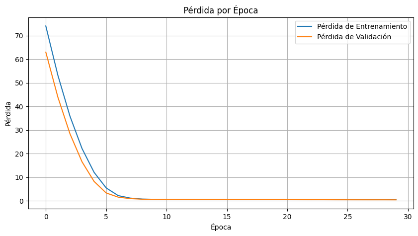

```python
# Gráficos de pérdida (loss)
plt.figure(figsize=(10, 5))
plt.plot(history_dict['loss'], label='Pérdida de Entrenamiento')
plt.plot(history_dict['val_loss'], label='Pérdida de Validación')
plt.title('Pérdida por Época')
plt.xlabel('Época')
plt.ylabel('Pérdida')
plt.legend()
plt.grid()
plt.show()
```

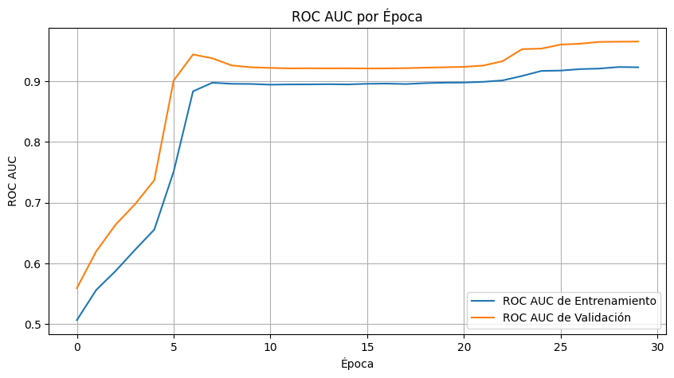

```python
# Verificar si 'AUC' y 'val_AUC' están en history_dict
if 'AUC' in history_dict:
    plt.figure(figsize=(10, 5))
    plt.plot(history_dict['AUC'], label='ROC AUC de Entrenamiento')
    plt.plot(history_dict['val_AUC'], label='ROC AUC de Validación')
    plt.title('ROC AUC por Época')
    plt.xlabel('Época')
    plt.ylabel('ROC AUC')
    plt.legend()
    plt.grid()
    plt.show()
else:
    print("La métrica ROC AUC no está disponible en history.history.")
```

```python
# Evaluación del modeolo de forma automática con '.evaluate' o de forma manual (de forma automática calcula internamente un predict y lo compara con los valores verdaderos)

# Evaluación con .evaluate
loss, roc_auc = model.evaluate(X_test_nn, y_test)

# Predicciones manuales
y_pred_proba = model.predict(X_test_nn)
roc_auc_manual = roc_auc_score(y_test, y_pred_proba)

print(f"ROC AUC (.evaluate): {roc_auc:.4f}")
print(f"ROC AUC (manual): {roc_auc_manual:.4f}")
```

```
2774/2774 ━━━━━━━━━━━━━━━━━━━━ 4s 1ms/step - AUC: 0.9652 - loss: 0.3960
2774/2774 ━━━━━━━━━━━━━━━━━━━━ 3s 1ms/step
ROC AUC (.evaluate): 0.9653
ROC AUC (manual): 0.9653
```

```python
# Predecir probabilidades y convertirlas a etiquetas para calcular el informe de clasificación
y_pred_nn = (y_pred_proba > 0.5).astype(int)

# Reporte de clasificación
print(classification_report(y_test, y_pred_nn))
```

```
              precision    recall  f1-score   support

           0       0.98      1.00      0.99     79712
           1       0.96      0.82      0.89      9045

    accuracy                           0.98     88757
   macro avg       0.97      0.91      0.94     88757
weighted avg       0.98      0.98      0.98     88757
```

### 9. GUARDAMOS EL MODELO

```python
with open('clasificador_lr_PD', 'wb') as f:
    pickle.dump(model_lr, f)
```

```python
with open('clasificador_rf_PD', 'wb') as f:
    pickle.dump(model_rf, f)
```

```python
with open('clasificador_xgb_PD', 'wb') as f:
    pickle.dump(model_xgb, f)
```

```python
#PARA LA RED NEURONAL no hace falta guardar el modelo porque ya hemos incluido un callback en el código de la red neuronal que guarda automáticamente el modelo

# model.save('clasificador_nn.keras',include_optimizer=False)
```

### 10. PREDECIR SOBRE EL CONJUNTO DE EXPLOTACIÓN

Creamos una función para evaluar el rendimiento de los modelos de ML

```python
def plot_confusion_matrix(y_true, y_pred, title):
    cm = confusion_matrix(y_true, y_pred)

    labels = np.array([[f"TN\n{cm[0, 0]}", f"FP\n{cm[0, 1]}"], [f"FN\n{cm[1, 0]}", f"TP\n{cm[1, 1]}"]])

    plt.figure(figsize=(8, 6))
    sns.heatmap(cm, annot=labels, fmt="", cmap="Blues", xticklabels=["No Default (0)", "Default (1)"], yticklabels=["No Default (0)", "Default (1)"])
    plt.xlabel("Predicción")
    plt.ylabel("Valor Real")
    plt.title(f"Matriz de Confusión - {title}")
    plt.show()

def evaluate_explotation(features_explot, target_explot, y_pred, y_proba):
    y_proba = y_proba[:, 1]  # Tomamos la probabilidad de la clase positiva (default = 1)

    roc_auc = roc_auc_score(target_explot, y_proba)
    print("\n--- Evaluación del Conjunto de Explotación ---")
    print("ROC AUC:", roc_auc)
    plot_confusion_matrix(target_explot, y_pred, title="Conjunto de Explotación")

    print("\nClassification Report:")
    print(classification_report(target_explot, y_pred))

    fpr, tpr, _ = roc_curve(target_explot, y_proba)
    plt.figure(figsize=(8, 6))
    plt.plot(fpr, tpr, label="Explot ROC (AUC = {:.2f})".format(roc_auc))
    plt.plot([0, 1], [0, 1], "k--", label="Random Guess")
    plt.xlabel("False Positive Rate")
    plt.ylabel("True Positive Rate")
    plt.title("ROC Curve - Conjunto de Explotación")
    plt.legend()
    plt.show()
```

**REGRESIÓN LOGÍSTICA**

```python
#Cargar el modelo
with open('clasificador_lr_PD', 'rb') as f:
    loaded_model = pickle.load(f)
```

```python
y_pred_lr = loaded_model.predict(features_explot_lasso)
y_proba_lr = loaded_model.predict_proba(features_explot_lasso)
```

```
--- Evaluación del Conjunto de Explotación ---
ROC AUC: 0.7937042632864634
```

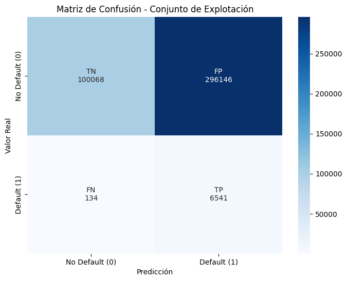

```
Classification Report:
              precision    recall  f1-score   support

           0       1.00      0.25      0.40    396214
           1       0.02      0.98      0.04      6675

    accuracy                           0.26    402889
   macro avg       0.51      0.62      0.22    402889
weighted avg       0.98      0.26      0.40    402889
```

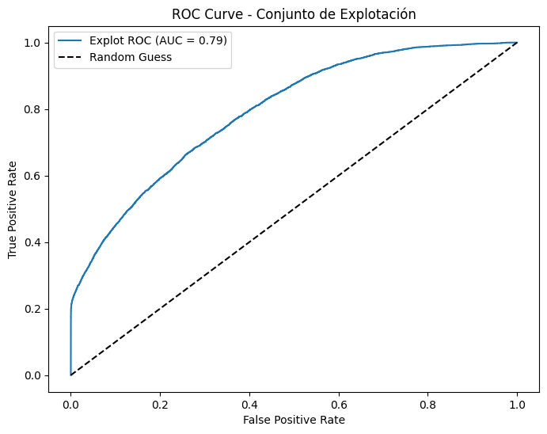

```python
evaluate_explotation(features_explot_lasso, target_explot, y_pred_lr, y_proba_lr)
```

En primer lugar destacar el score tan elevado que se obtiene sobre el el conjunto de explotación para un modelo tan siemple y explicativo como la regresión logística, siendo el ROC_AUC más elevado de todos los modelos analizados sobre el conjunto de explotación.  
Por otro lado también es importante mencionar que el modelo minimiza los Falso Negativos, es decir que el modelo prediga como No default pero que realmente sea Default, lo cuál tendría un gran coste para la entidad financiera puesto que supondría pérdidas. Mientras que el caso de Falso Positivo (el modelo predice Default y es NO default) tendría impacto en la rentabilidad, sería dinero que la entidad dejaría de ganar en una operación buena, lo cuál desde un punto de vista supervisor es menos relevante. Observamos que el modelo es muy bueno prediciendo los FN pero muy malo prediciendo los FP.

**RANDOM FOREST**

```python
#Cargar el modelo
with open('clasificador_rf_PD', 'rb') as f:
    loaded_model = pickle.load(f)
```

```python
y_pred_rf = loaded_model.predict(features_explot_rf)
y_proba_rf = loaded_model.predict_proba(features_explot_rf)
```

```
--- Evaluación del Conjunto de Explotación ---
ROC AUC: 0.7373044769492307
```

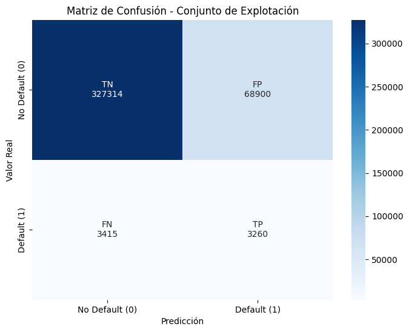

```
Classification Report:
              precision    recall  f1-score   support

           0       0.99      0.83      0.90    396214
           1       0.05      0.49      0.08      6675

    accuracy                           0.82    402889
   macro avg       0.52      0.66      0.49    402889
weighted avg       0.97      0.82      0.89    402889
```

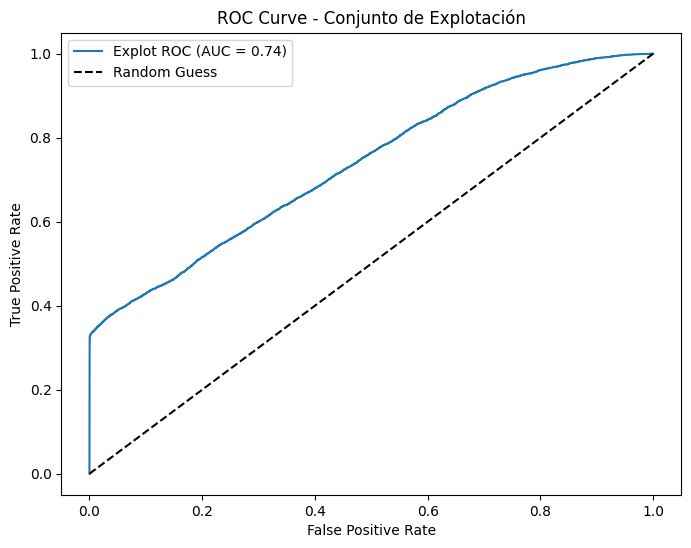

```python
evaluate_explotation(features_explot_rf, target_explot, y_pred_rf, y_proba_rf)
```

**XGBOOST**

```python
#Cargar el modelo
with open('clasificador_xgb_PD', 'rb') as f:
    loaded_model = pickle.load(f)
```

```python
y_pred_xgb = loaded_model.predict(features_explot_xgb)
y_proba_xgb = loaded_model.predict_proba(features_explot_xgb)
```

```
--- Evaluación del Conjunto de Explotación ---
ROC AUC: 0.7865042696538468
```

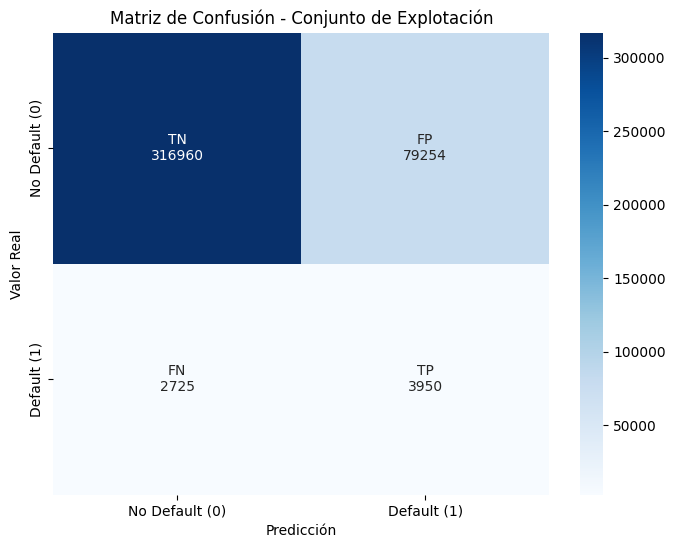

```
Classification Report:
              precision    recall  f1-score   support

           0       0.99      0.80      0.89    396214
           1       0.05      0.59      0.09      6675

    accuracy                           0.80    402889
   macro avg       0.52      0.70      0.49    402889
weighted avg       0.98      0.80      0.87    402889
```

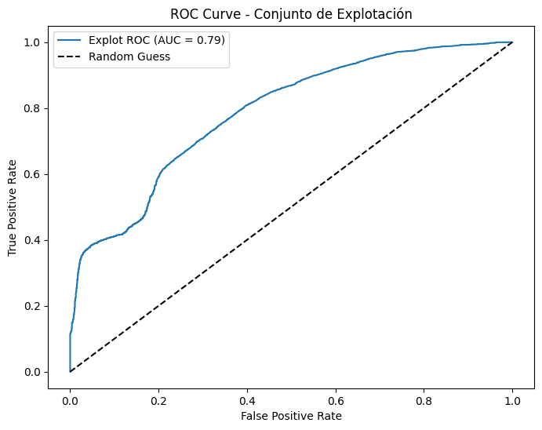

```python
evaluate_explotation(features_explot_xgb, target_explot, y_pred_xgb, y_proba_xgb)
```

**RED NEURONAL**

```python
def plot_confusion_matrix(y_true, y_pred, title):

    cm = confusion_matrix(y_true, y_pred)

    labels = np.array([[f"TN\n{cm[0, 0]}", f"FP\n{cm[0, 1]}"], [f"FN\n{cm[1, 0]}", f"TP\n{cm[1, 1]}"]])

    plt.figure(figsize=(8, 6))
    sns.heatmap(cm, annot=labels, fmt="", cmap="Blues", xticklabels=["No Default (0)", "Default (1)"], yticklabels=["No Default (0)", "Default (1)"])
    plt.xlabel("Predicción")
    plt.ylabel("Valor Real")
    plt.title(f"Matriz de Confusión - {title}")
    plt.show()





def evaluate_explotation_nn(features_explot_nn, target_explot, y_pred_nn, y_pred_proba_nn):
    # Calcular el ROC AUC
    roc_auc = roc_auc_score(target_explot, y_pred_proba_nn) if y_pred_proba_nn is not None else "N/A"

    print("\n--- Evaluación del Conjunto de Explotación ---")
    print("ROC AUC:", roc_auc)
    plot_confusion_matrix(target_explot, y_pred_nn, title="Conjunto de Explotación")

    print("\nClassification Report:")
    print(classification_report(target_explot, y_pred_nn))

    # Curva ROC (si se proporcionaron probabilidades)
    if y_pred_proba_nn is not None:
        fpr, tpr, _ = roc_curve(target_explot, y_pred_proba_nn)
        plt.figure(figsize=(8, 6))
        plt.plot(fpr, tpr, label="Explot ROC (AUC = {:.2f})".format(roc_auc))
        plt.plot([0, 1], [0, 1], "k--", label="Random Guess")
        plt.xlabel("False Positive Rate")
        plt.ylabel("True Positive Rate")
        plt.title("ROC Curve - Conjunto de Explotación")
        plt.legend()
        plt.show()
```

```python
#RED NEURONAL
#cargar el modelo
modelo_cargado = load_model("clasificador_nn_PD.keras")
```

```python
#RED NEURONAL

# Evaluación con .evaluate
loss, roc_auc = modelo_cargado.evaluate(features_explot_nn, target_explot)

# Predicciones manuales
y_pred_proba_nn = modelo_cargado.predict(features_explot_nn)  #en redes neuronales no existe el predict_proba, la probabilidades se calculan con predict
roc_auc_manual = roc_auc_score(target_explot, y_pred_proba_nn)

print(f"ROC AUC (.evaluate): {roc_auc:.4f}")
print(f"ROC AUC (manual): {roc_auc_manual:.4f}")
```

```
12591/12591 ━━━━━━━━━━━━━━━━━━━━ 18s 1ms/step - AUC: 0.5660 - loss: 1.5700
12591/12591 ━━━━━━━━━━━━━━━━━━━━ 12s 985us/step
ROC AUC (.evaluate): 0.7594
ROC AUC (manual): 0.7594
```

```python
#RED NEURONAL

# Predecir probabilidades y convertirlas a etiquetas para calcular el informe de clasificación
y_pred_nn = (y_pred_proba_nn > 0.5).astype(int)

# Reporte de clasificación
print(classification_report(target_explot, y_pred_nn))
```

```
              precision    recall  f1-score   support

           0       1.00      0.37      0.54    396214
           1       0.02      0.91      0.05      6675

    accuracy                           0.38    402889
   macro avg       0.51      0.64      0.30    402889
weighted avg       0.98      0.38      0.54    402889
```

- **model.evaluate()**: Calcula el ROC AUC durante la evaluación usando las implementaciones internas de TensorFlow/Keras. La implementación de TensorFlow podría tener diferencias sutiles, como el manejo de pequeños errores numéricos o el cálculo del área bajo la curva.
- **roc_auc_score** de sklearn: Usa directamente las probabilidades predichas de model.predict() y calcula el área bajo la curva exacta según los valores proporcionados.

La forma en que se manejan los valores de probabilidad predichos puede afectar ligeramente el cálculo del ROC AUC. Por ejemplo, si las predicciones extremas están más cerca de 0.999 o 0.001, roc_auc_score las interpreta como tal, mientras que .evaluate() podría manejarlas con menos precisión.

Por lo que cómo conclusión, si queremos tener registro total de cómo se han calculado las métricas es preferible emplear la forma manual.

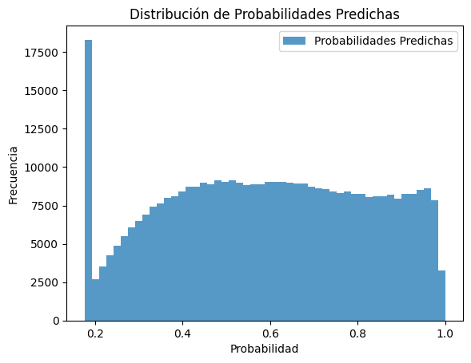

```python
#RED NEURONAL

plt.hist(y_pred_proba_nn, bins=50, alpha=0.75, label='Probabilidades Predichas')
plt.xlabel('Probabilidad')
plt.ylabel('Frecuencia')
plt.title('Distribución de Probabilidades Predichas')
plt.legend()
plt.show()
```

```
--- Evaluación del Conjunto de Explotación ---
ROC AUC: 0.759413656627016
```

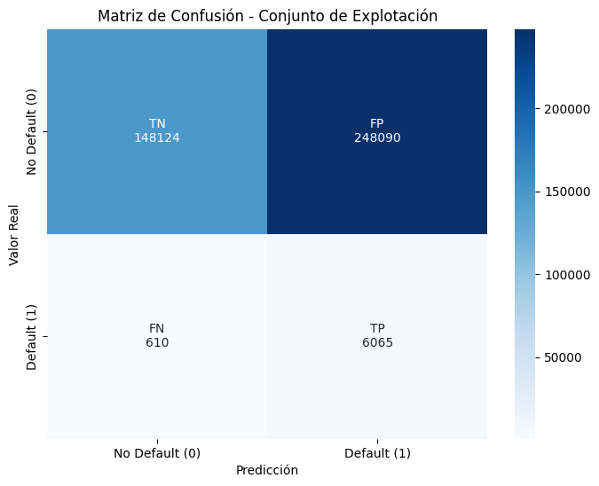

```
Classification Report:
              precision    recall  f1-score   support

           0       1.00      0.37      0.54    396214
           1       0.02      0.91      0.05      6675

    accuracy                           0.38    402889
   macro avg       0.51      0.64      0.30    402889
weighted avg       0.98      0.38      0.54    402889
```

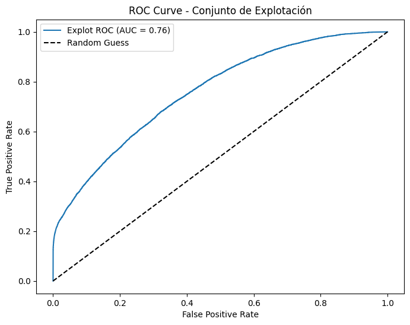

```python
#RED NEURONAL
evaluate_explotation_nn(features_explot_nn, target_explot, y_pred_nn, y_pred_proba_nn)
```

Debido a que no hemos utilizado ninguna técnica de reducción de la dimensionalidad previo al entrenamiento de la red neuronal (ya que no es aconsejable, puesto que las redes es preferible entrenarlas con todas las variables y que sea la propia red la que seleccione automáticamente las variables), debemos emplear alguna técnica para explicar las predicciones de la red

**SHAP**

SHAP (SHapley Additive Explanations) es un método de interpretabilidad de modelos de Machine Learning basado en la teoría de juegos de Shapley. Permite explicar cómo cada variable influye en la predicción de un modelo, ayudando a entender la importancia y el impacto de las características en modelos complejos (redes neuronales, XGBoost, Random Forest, ...).

- Usa la Teoría de Juegos de Shapley, donde cada variable es tratada como un "jugador" que contribuye a la predicción final.
- SHAP calcula cuánto cambia la predicción cuando una variable se incluye o se excluye del modelo.
- Los valores SHAP positivos aumentan la predicción, los negativos la reducen.

El principal inconveniente de Shap para un dataset de la dimensiones de este (400.000 filas y 70 columnas aprox) es que el cálculo es muy lento usando instancias CPU de AWS como es el caso. Por lo que sería conveniente correr el código de SHAP con alguna instancia más potente con GPU, como es el caso de las instancias **p3.2xlarge** (1 GPU NVIDIA V100, 8 vCPUs, 61 GB RAM), ideales para procesos de Deep Learning.

# ACTIVAR EL CÓDIGO CUANDO USEMOS LA INSTANCIA p3.2xlarge

```python
# # Asegurar que los datos de explotación están en formato numpy
# features_explot_np = features_explot_filtered.to_numpy().astype(np.float32)

# # Seleccionar una muestra de datos para SHAP (para mejorar eficiencia)
# background_data = shap.sample(features_explot_np, min(500, features_explot_np.shape[0]))

# # Convertir background_data a tensor de TensorFlow para compatibilidad con el modelo
# background_data = tf.convert_to_tensor(background_data, dtype=tf.float32)

# # Crear el SHAP Explainer con modelo_cargado.predict para eficiencia en redes neuronales
# tf_explainer = shap.Explainer(modelo_cargado.predict, background_data)

# # Definir parámetros para procesamiento en lotes
# batch_size = 50000  # Ajustar según la memoria disponible
# num_batches = int(np.ceil(features_explot_np.shape[0] / batch_size))
# shap_values_list = []
# shap_values_gpu = []

# # Procesar en lotes para reducir consumo de memoria
# print(f"Procesando SHAP en {num_batches} lotes...")
# for i in range(num_batches):
#     with tf.device('/GPU:0'):
#     start = i * batch_size
#     end = min((i + 1) * batch_size, features_explot_np.shape[0])
#     if i == 0:
#         print(f"Lote {i+1}/{num_batches}: {start} - {end}")

#     batch_data = features_explot_np[start:end]
#             shap_values_batch = tf_explainer(batch_data)
#         shap_values_gpu.append(shap_values_batch.values)
#     shap_values_list.append(shap_values_batch.values)

# # Unir los valores SHAP de todos los lotes
# shap_values = np.concatenate(shap_values_gpu, axis=0)

# # Obtener importancia promedio de las variables
# shap_importance = np.abs(shap_values).mean(axis=0)

# # Crear DataFrame con la importancia de las variables
# shap_df = pd.DataFrame({'Feature': features_explot_filtered.columns, 'SHAP Importance': shap_importance})
# shap_df = shap_df.sort_values(by='SHAP Importance', ascending=False)

# # Seleccionar solo las 20 variables más importantes
# top_n = 20
# selected_features = shap_df['Feature'].head(top_n).values

# # Gráfico de resumen de SHAP con las variables más importantes
# shap.summary_plot(shap_values[:, :top_n], features_explot_np[:, :top_n], feature_names=selected_features)
```

### 11. ÍNDICE DE ESTABILIDAD PROBLACIONAL

El Population Stability Index (PSI) es una métrica utilizada para medir si la distribución de una variable ha cambiado significativamente entre dos poblaciones.  
El PSI se calcula comparando las frecuencias de bins en dos distribuciones:

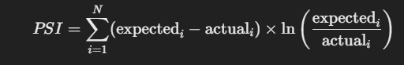

Donde:

- expected = Distribución de referencia (por ejemplo, datos de entrenamiento).
- actual = Nueva distribución (por ejemplo, datos de validación o nuevos clientes).
- N = Número de bins en la variable.
- ln() = Logaritmo natural.

Se obtiene un valor único para el Índice de Estabilidad:

- Si este valor es menor a 0,1 --> las dos muestras poseen características similares.
- Un valor entre 0,1 y 0,25 --> alerta de que el índice ha de ser observado por si eleva su valor.
- Un valor mayor a 0,25 expresa una diferencia sustancial entre las características de las dos muestras.

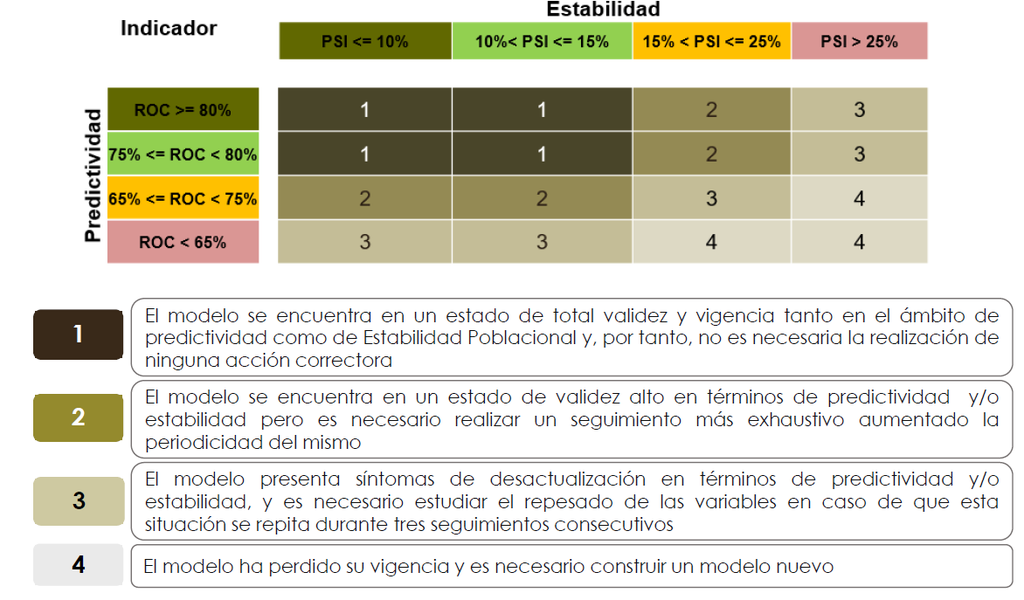

```python
def calculate_psi(expected, actual, bins=10):

    # Definir los bins basados en los datos esperados
    bins_edges = np.linspace(min(expected), max(expected), bins + 1)

    # Obtener proporciones en cada bin
    expected_dist, _ = np.histogram(expected, bins=bins_edges)
    actual_dist, _ = np.histogram(actual, bins=bins_edges)

    # Convertir a proporciones
    expected_dist = expected_dist / sum(expected_dist)
    actual_dist = actual_dist / sum(actual_dist)

    # Reemplazar ceros para evitar división por cero o log(0)
    expected_dist = np.where(expected_dist == 0, 0.0001, expected_dist)
    actual_dist = np.where(actual_dist == 0, 0.0001, actual_dist)

    # Calcular PSI
    psi_values = (expected_dist - actual_dist) * np.log(expected_dist / actual_dist)
    psi = np.sum(psi_values)

    return psi
```

Comparamos la PD estimada por elos modelos de ML para el conjunto de entrenamiento y el de explotación y vemos la diferencia de las distribuciones

```python
#REGRESIÓN LOGÍSTICA
calculate_psi(y_train_pred_lr, y_pred_lr)
```

```
2.228019603685029
```

```python
#RANDOM FOREST
calculate_psi(y_train_pred_rf, y_pred_rf)
```

```
0.04648322377079111
```

```python
#XGBOOST
calculate_psi(y_train_pred_xgb, y_pred_xgb)
```

```
0.099289136431865
```

Comparamos la PD estimada por el último modelo **red neuronal** para el conjunto de entrenamiento y el de explotación y vemos la diferencia de las distribuciones

```python
y_pred_proba = modelo_cargado.predict(X_train_nn)
y_pred_nn_train = (y_pred_proba > 0.5).astype(int)
```

```
11095/11095 ━━━━━━━━━━━━━━━━━━━━ 11s 989us/step
```

```python
psi_score = calculate_psi(y_pred_nn_train.ravel(), y_pred_nn.ravel())
psi_score
```

```
1.5650739641627838
```

### 12. GUARDAR FEATURES EXPLOTACIÓN Y PD ESTIMADA EN CSV

Una vez ya tenemos las PDs estimadas para cada acreditado del conjunto de explotación (`y_pred` para modelos ML e `y_pred_nn` para el modelo IA), vamos a llevar a cabo una agrupación por caracteristicas del acreditado, para crear buckets. Sólamente vamos a tener en cuenta las variables más importantes que obtuvimos en el paso de reducción de la dimensionalidad, además lógicamente de la PD estimada por los modelos.  
Posteriormente compararemos la PD media de cada bucket con la Tasa de default real media por bucket y la iremos ajustando.

**PROBABILIDAD DE DEFAULT ESTIMADA POR MODELO ML**

Nos quedamos sólo con la probabilidad de hacer default

```python
#REGRESIÓN LOGÍSTICA

PD_modelo_lr = y_proba_lr[:, 1]
PD_modelo_lr
```

```
array([0.94290498, 0.62458398, 0.53086436, ..., 0.6697897 , 0.70905335,
       0.42932634])
```

```python
#RANDOM ROREST

PD_modelo_rf = y_proba_rf[:, 1]
PD_modelo_rf
```

```
array([0.56900456, 0.42053198, 0.2898924 , ..., 0.33002786, 0.38500783,
       0.19968453])
```

```python
#XGBOOST

PD_modelo_xgb = y_proba_xgb[:, 1]
PD_modelo_xgb
```

```
array([0.99992466, 0.9934576 , 0.73423237, ..., 0.09451985, 0.11678078,
       0.14284025], dtype=float32)
```

**PROBABILIDAD DE DEFAULT ESTIMADA POR MODELO RED NEURONAL**

En la red neuronal ya tenemos directamente la columna de la probabilidad de default

```python
PD_modelo_nn  = y_pred_proba_nn.flatten()
PD_modelo_nn
```

```
array([0.9731026 , 0.5835184 , 0.50135684, ..., 0.4366098 , 0.468336  ,
       0.43264565], dtype=float32)
```

Añadimos las PD estimadas al dataset de la variables más importantes y pasamos los dfs a csv

```python
features_explot_lasso['PD_estimada'] = PD_modelo_lr
features_explot_rf['PD_estimada'] = PD_modelo_rf
features_explot_xgb['PD_estimada'] = PD_modelo_xgb
features_explot_nn['PD_estimada'] = PD_modelo_nn
```

Guardamos los nuevos datasets en 4 ficheros csv, uno para cada modelo

```python
features_explot_lasso.to_csv("df_PD_lr.csv", index=False)
features_explot_rf.to_csv("df_PD_rf.csv", index=False)
features_explot_xgb.to_csv("df_PD_xgb.csv", index=False)
features_explot_nn.to_csv("df_PD_nn.csv", index=False)
```